# Avocado Price Modelling

Colin Scotland | DE13

```
## [1] "C:/Users/colin/Documents/CodeClan/codeclan_homework_ColinS/week_10/weekend_hw"
```

```r
avocados <- read_csv(here("1_weekend_homework_part1/data/avocado.csv")) %>%
  janitor::clean_names()
```

```
## * `` -> ...1
```

```r
avocados
```

```
## # A tibble: 18,249 x 14
##       x1 date       average_price total_volume x4046   x4225 x4770 total_bags
##    <dbl> <date>             <dbl>        <dbl> <dbl>   <dbl> <dbl>      <dbl>
##  1     0 2015-12-27          1.33       64237. 1037.  54455.  48.2      8697.
##  2     1 2015-12-20          1.35       54877.  674.  44639.  58.3      9506.
##  3     2 2015-12-13          0.93      118220.  795. 109150. 130.       8145.
##  4     3 2015-12-06          1.08       78992. 1132   71976.  72.6      5811.
##  5     4 2015-11-29          1.28       51040.  941.  43838.  75.8      6184.
##  6     5 2015-11-22          1.26       55980. 1184.  48068.  43.6      6684.
##  7     6 2015-11-15          0.99       83454. 1369.  73673.  93.3      8319.
##  8     7 2015-11-08          0.98      109428.  704. 101815.  80        6829.
##  9     8 2015-11-01          1.02       99811. 1022.  87316.  85.3     11388.
## 10     9 2015-10-25          1.07       74339.  842.  64757. 113        8626.
## # ... with 18,239 more rows, and 6 more variables: small_bags <dbl>,
## #   large_bags <dbl>, x_large_bags <dbl>, type <chr>, year <dbl>, region <chr>
```

Check for NAs in the data set;

```r
avocados %>%
  summarise(across(.cols = everything(), ~ sum(is.na(.))))
```

```
## # A tibble: 1 x 14
##      x1  date average_price total_volume x4046 x4225 x4770 total_bags small_bags
##   <int> <int>         <int>        <int> <int> <int> <int>      <int>      <int>
## 1     0     0             0            0     0     0     0          0          0
## # ... with 5 more variables: large_bags <int>, x_large_bags <int>, type <int>,
## #   year <int>, region <int>
```

So there are no NAs to consider.

## Make a test set

The data consists of > 18k observations, so there should be plenty of capacity to create a test set. 10% of 18k is around 1800 observations, which sounds like a reasonable size for a test set.

Make a test index using 10% of the data;

```r
avocado_row_count <- nrow(avocados)

test_index <- sample(1:avocado_row_count, size = avocado_row_count * 0.1)
```

Then create the test and train data sets using this index;

```r
avo_test <- slice(avocados, test_index)
avo_train <- slice(avocados, -test_index)
```

Adjust date into month only;

```r
avo_train <- avo_train %>%
  mutate(month = month(as.POSIXlt(date), label = FALSE)) %>%
  mutate(type = as.factor(type),
         month = as.factor(month))
```

Tidy up other unnecessary columns;

```r
avo_train <- avo_train %>%
  select(-c(x1, date, region, total_bags))
```

Start to build forwards using `leaps()`;

```r
regsubsets_forward <- regsubsets(average_price ~ .,
                                 data = avo_train,
                                 nvmax = 20,
                                 method = "forward")
```

```r
sum_regsubsets_forward <- summary(regsubsets_forward)
sum_regsubsets_forward
```

```
## Subset selection object
## Call: regsubsets.formula(average_price ~ ., data = avo_train, nvmax = 20,
##     method = "forward")
## 20 Variables  (and intercept)
##              Forced in Forced out
## total_volume     FALSE      FALSE
## x4046            FALSE      FALSE
## x4225            FALSE      FALSE
## x4770            FALSE      FALSE
## small_bags       FALSE      FALSE
## large_bags       FALSE      FALSE
## x_large_bags     FALSE      FALSE
## typeorganic      FALSE      FALSE
## year             FALSE      FALSE
## month2           FALSE      FALSE
## month3           FALSE      FALSE
## month4           FALSE      FALSE
## month5           FALSE      FALSE
## month6           FALSE      FALSE
## month7           FALSE      FALSE
## month8           FALSE      FALSE
## month9           FALSE      FALSE
## month10          FALSE      FALSE
## month11          FALSE      FALSE
## month12          FALSE      FALSE
## 1 subsets of each size up to 20
## Selection Algorithm: forward
##           total_volume x4046 x4225 x4770 small_bags large_bags x_large_bags
## 1  ( 1 )  " "          " "   " "   " "   " "        " "        " "
## 2  ( 1 )  " "          " "   " "   " "   " "        " "        " "
## 3  ( 1 )  " "          " "   " "   " "   " "        " "        " "
## 4  ( 1 )  " "          " "   " "   " "   " "        " "        " "
## 5  ( 1 )  " "          " "   " "   " "   " "        " "        " "
## 6  ( 1 )  " "          " "   " "   " "   " "        " "        " "
## 7  ( 1 )  " "          " "   " "   " "   " "        " "        " "
## 8  ( 1 )  " "          " "   " "   " "   " "        " "        " "
## 9  ( 1 )  " "          "*"   " "   " "   " "        " "        " "
## 10  ( 1 ) " "          "*"   "*"   " "   " "        " "        " "
## 11  ( 1 ) " "          "*"   "*"   " "   " "        " "        " "
## 12  ( 1 ) " "          "*"   "*"   " "   " "        " "        " "
```

[output cut: 35 more lines]

```
## 6  ( 1 )  "*"    "*"     " "     " "
## 7  ( 1 )  "*"    "*"     " "     " "
## 8  ( 1 )  "*"    "*"     "*"     " "
## 9  ( 1 )  "*"    "*"     "*"     " "
## 10  ( 1 ) "*"    "*"     "*"     " "
## 11  ( 1 ) "*"    "*"     "*"     " "
## 12  ( 1 ) "*"    "*"     "*"     " "
## 13  ( 1 ) "*"    "*"     "*"     " "
## 14  ( 1 ) "*"    "*"     "*"     " "
## 15  ( 1 ) "*"    "*"     "*"     " "
## 16  ( 1 ) "*"    "*"     "*"     " "
## 17  ( 1 ) "*"    "*"     "*"     "*"
## 18  ( 1 ) "*"    "*"     "*"     "*"
## 19  ( 1 ) "*"    "*"     "*"     "*"
## 20  ( 1 ) "*"    "*"     "*"     "*"
```

It looks like the most significant predictors are `type` and `month`, with `x4046` and `x4225` also showing some contribution albeit less significantly.

In another view;

```r
sum_regsubsets_forward$which
```

```
##    (Intercept) total_volume x4046 x4225 x4770 small_bags large_bags
## 1         TRUE        FALSE FALSE FALSE FALSE      FALSE      FALSE
## 2         TRUE        FALSE FALSE FALSE FALSE      FALSE      FALSE
## 3         TRUE        FALSE FALSE FALSE FALSE      FALSE      FALSE
## 4         TRUE        FALSE FALSE FALSE FALSE      FALSE      FALSE
## 5         TRUE        FALSE FALSE FALSE FALSE      FALSE      FALSE
## 6         TRUE        FALSE FALSE FALSE FALSE      FALSE      FALSE
## 7         TRUE        FALSE FALSE FALSE FALSE      FALSE      FALSE
## 8         TRUE        FALSE FALSE FALSE FALSE      FALSE      FALSE
## 9         TRUE        FALSE  TRUE FALSE FALSE      FALSE      FALSE
## 10        TRUE        FALSE  TRUE  TRUE FALSE      FALSE      FALSE
## 11        TRUE        FALSE  TRUE  TRUE FALSE      FALSE      FALSE
## 12        TRUE        FALSE  TRUE  TRUE FALSE      FALSE      FALSE
## 13        TRUE        FALSE  TRUE  TRUE FALSE      FALSE      FALSE
## 14        TRUE        FALSE  TRUE  TRUE  TRUE      FALSE      FALSE
```

[output cut: 48 more lines]

Visually;

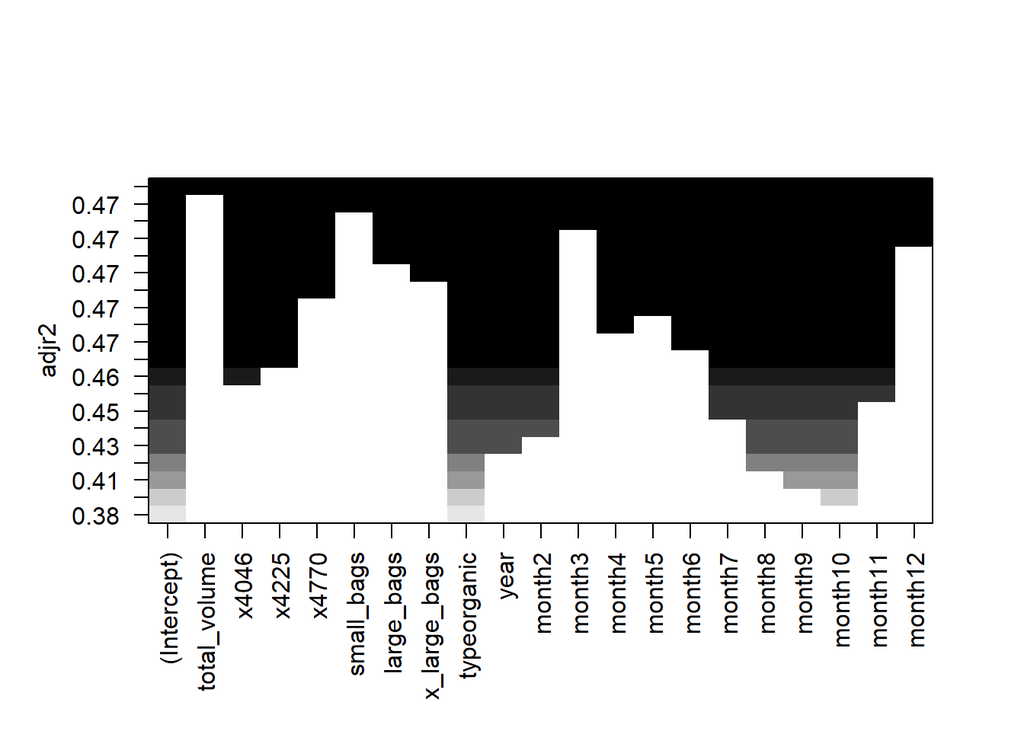

```r
plot(regsubsets_forward, scale = "adjr2")
```

Visualising this with BIC;

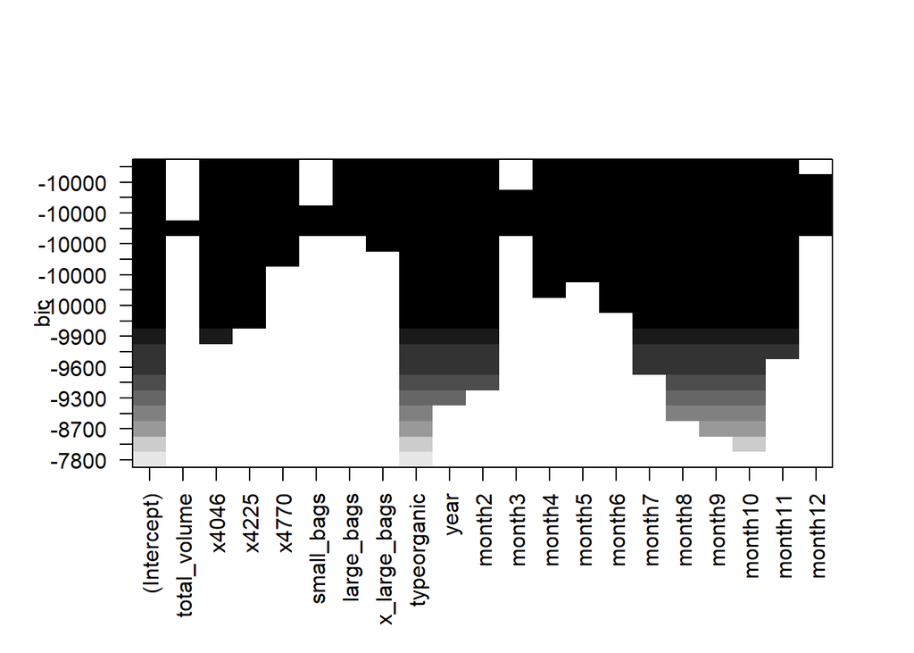

```r
plot(regsubsets_forward, scale = "bic")
```

Plot r-squared as a function of number of predictors;

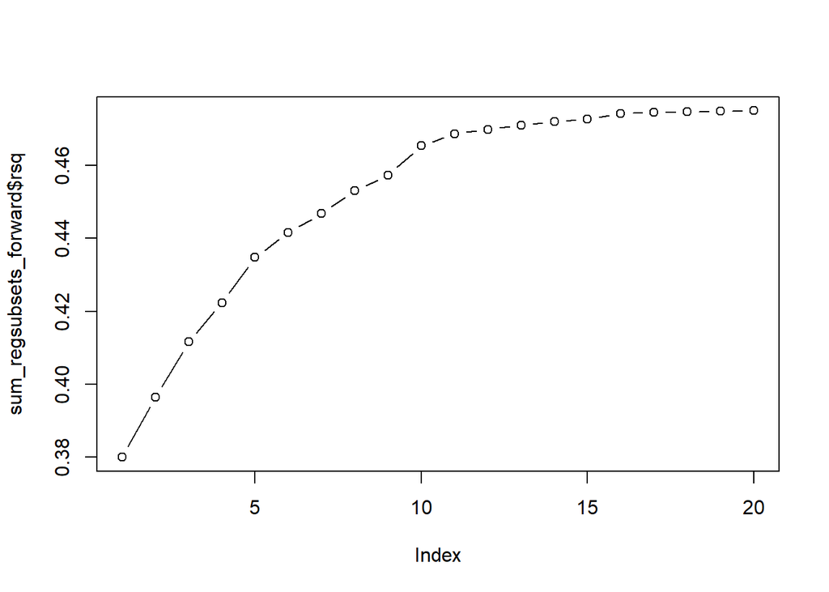

```r
plot(sum_regsubsets_forward$rsq, type = "b")
```

And compare nummber of predictors to BIC;

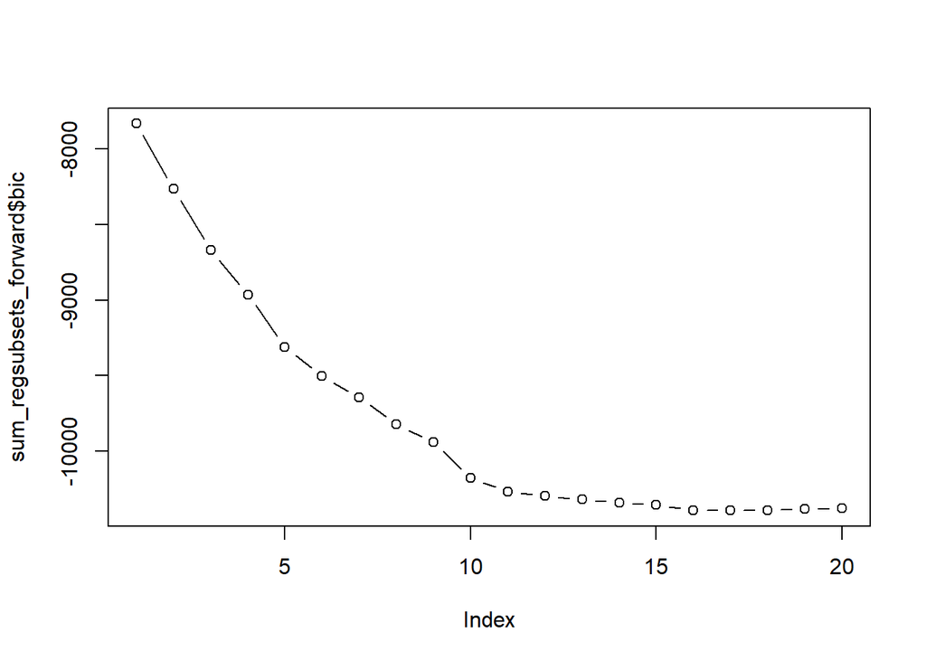

```r
plot(sum_regsubsets_forward$bic, type = "b")
```